# Visualisering af antal sagte ord

pmd

Før vi begynder, skal vi indlæse de udvidelsespakker til R, som vi vil benytte. Til sidst i denne kodeblok indlæser vi også de R funktioner vi har skrevet til dette projekt ved at `source` filen `src/p017-functions.R`.

```r
library(tidyverse)
library(tidytext)
library(readxl)
library(here)
library(ndjson)
library(xslt)
library(fs)
library(ggplot2)

require(readr)  # for read_csv()
require(purrr)  # for map(), reduce()

source(here("src/p017-functions.R"))
source(here("src/visalisering_ord_sagt_functions.R"))
```

# Indlæs data

Vi kan nu benytte en af P017 funktionerne til at indlæse alle de Holberg stykker, som vi har liggende i `test-data` mappen. Vi laver en tabel med navnet plays.

```r
here()
```

```
[1] "/home/baj/Projects/P017_R_Project"
```

```r
#convert_TEI_to_JSONL(here("test-data"))
read_plays_jsonl(here("test-data")) -> plays
```

For at gøre det nemmere for os selv, starter vi med kun at se på ét skuespil “my_play” (fx Barselsstuen). Vi filtrerer ikke længere efter titel. Vi indlæser direkte fra JSON-filen! Forhåbentlig er “my_file” det eneste sted vi skal ændre for at lave visualiseringen for et andet skuespil :)

```r
# my_file <- "GertWestphaler1724_mod.jsonl"
# my_file <- "Bondedreng_mod.jsonl"
my_file <- "Mascarade_mod.jsonl"
# my_file <- "Barselstuen_mod.jsonl"
# my_file <- "Ulysses_mod.jsonl"
# my_file <- "uden_hoved_og_hale_mod.jsonl"
# my_file <- "Skibbrud_mod.jsonl"
# my_file <- "Sganarel_mod.jsonl"
# my_file <- "Republiqven_mod.jsonl"
# my_file <- "Ranudo_mod.jsonl"
# my_file <- "Plutus_mod.jsonl"
# my_file <- "Philosophus_mod.jsonl"
# my_file <- "Pernille_mod.jsonl"
# todo den her virker ikke: my_file <- "Nytaarsprolog_mod.jsonl"
# my_file <- "Melampe_mod.jsonl"
# my_file <- "Ligbeg_mod.jsonl"
# my_file <- "Kilde-Reysen_mod.jsonl"
# my_file <- "Kandst_mod.jsonl" todo udfordring med 1. og 2. <w>rådsherreinde</w>
# my_file <- "Juele-Stue_mod.jsonl"
# todo den her virker heller ikke: my_file <- "JJ_Bet_1723_mod.jsonl"
# my_file <- "Jeppe_mod.jsonl"
# my_file <- "Jean_de_France_mod.jsonl"
# my_file <- "Jacob_von_Tyboe_mod.jsonl"
# my_file <- "Hexerie_mod.jsonl"
# my_file <- "Henrick_og_Pernille_mod.jsonl"
# my_file <- "GertWestphaler1723_mod.jsonl"
# my_file <- "Erasmus_mod.jsonl"
# my_file <- "Diderich_mod.jsonl"
# my_file <- "Det_Arabiske_Pulver_mod.jsonl"
# my_file <- "Den_Vaegelsindede_1731_mod.jsonl"
# my_file <- "De_u-synlige_mod.jsonl"
# my_file <- "Den_Vaegelsindede_1723_mod.jsonl"
# my_file <- "Den_Stundesloese_mod.jsonl"
# my_file <- "Den_Honnette_Ambition_mod.jsonl"
# my_file <- "Den_11_Junii_mod.jsonl"
# my_file <- "Brudgom_mod.jsonl"
# my_file <- "Abracadabra_mod.jsonl"
my_play <- read_play_jsonl(here("test-data", my_file))
my_play
```

| filename | act | act_number | docTitle | index | scene | scene_number | speaker | speaker_stage | spoke | stage | title | type | year |
| --- | --- | --- | --- | --- | --- | --- | --- | --- | --- | --- | --- | --- | --- |
| Mascarade_mod.jsonl | Første akt | 1 | Maskerade Komedie | 1 | Scene 1 | 1 | NA | NA | NA | Leander, Henrik | Maskerade | 1 | (1724) |
| Mascarade_mod.jsonl | Første akt | 1 | Maskerade Komedie | 2 | Scene 1 | 1 | Leander | (i sin slåbrok gnikkende sine øjne) | NA | NA | Maskerade | 3 | (1724) |
| Mascarade_mod.jsonl | Første akt | 1 | Maskerade Komedie | 3 | Scene 1 | 1 | Leander | NA | Henrik, hvad er klokken? | NA | Maskerade | 4 | (1724) |
| Mascarade_mod.jsonl | Første akt | 1 | Maskerade Komedie | 4 | Scene 1 | 1 | Henrik | (gispende) | NA | NA | Maskerade | 3 | (1724) |
| Mascarade_mod.jsonl | Første akt | 1 | Maskerade Komedie | 5 | Scene 1 | 1 | Henrik | NA | Klokken går nok til frokost, herre, men jeg ved ikke hvorfor vi skal stå så tidlig op. Se engang på uret, herre. | NA | Maskerade | 4 | (1724) |
| Mascarade_mod.jsonl | Første akt | 1 | Maskerade Komedie | 6 | Scene 1 | 1 | Leander | NA | Hillemænd! Er det muligt? Skulle vi kunne have sovet så længe, fire timer over middag? Min klokke står på fire. | NA | Maskerade | 4 | (1724) |
| Mascarade_mod.jsonl | Første akt | 1 | Maskerade Komedie | 7 | Scene 1 | 1 | Henrik | NA | Ej, det er ikke muligt, herre, det må være klokken fire om morgenen. | NA | Maskerade | 4 | (1724) |
| Mascarade_mod.jsonl | Første akt | 1 | Maskerade Komedie | 8 | Scene 1 | 1 | Leander | NA | Du skal nok se at det er så lyst klokken fire i januar måned! | NA | Maskerade | 4 | (1724) |
| Mascarade_mod.jsonl | Første akt | 1 | Maskerade Komedie | 9 | Scene 1 | 1 | Henrik | NA | Så må solen ikke gå rigtig da. Det kan jo umuligt være eftermiddag; thi nu stod vi først op. | NA | Maskerade | 4 | (1724) |
| Mascarade_mod.jsonl | Første akt | 1 | Maskerade Komedie | 10 | Scene 1 | 1 | Leander | NA | Om solen går ikke ret, så ved jeg dog at mit ur ikke løber også gal; thi det er et engelsk ur. | NA | Maskerade | 4 | (1724) |

[output cut: 800 more lines]

# Gør data klar til visualisering

I et skuespil lader vi scene være den tidsmæssige udvikling. Så vi tæller hvad hver rolle siger for hver scene.

Hvor mange dialoger er der pr. scene?

```r
my_play %>%
  count(act_number, scene_number)
```

| act_number | scene_number | n |
| --- | --- | --- |
| 1 | 1 | 16 |
| 1 | 2 | 39 |
| 1 | 3 | 20 |
| 1 | 4 | 28 |
| 1 | 5 | 19 |
| 1 | 6 | 9 |
| 1 | 7 | 7 |
| 1 | 8 | 9 |
| 1 | 9 | 3 |
| 1 | 10 | 25 |

[output cut: 22 more lines]

## Tilføj scene indeks

Da vi ønsker at visualisere, hvor meget der tales over tid, har vi brug for et tal, der repræsenterer denne tid. Dette tal lader vi være et indeks for hver scene, som vi beregner i det følgende.

Først skal vi have beregnet antallet af scener i hver akt. Det gøres med følgende kode.

```r
my_play %>%
   group_by(act_number)  %>%
   summarise(scenes = max(scene_number)) %>%
   pull(scenes) %>% cumsum() -> act_length

act_length
```

```
[1] 11 19 32
```

Vi kan nu lave en funktion, som givet et aktnummer og scenenummer kan beregne den givne scenes nummer i sekvensen af alle scener

```r
calc_scene_index <- function(act_number, scene_number, act_length) {
   ifelse(is.numeric(scene_number),
      scene_number + ifelse(act_number==1, 0, act_length[act_number-1]),
      NA
   )
}
```

Vi bruger den som følger til at finde fx hvilket indeks den 4. scene i akt 3 har

```r
calc_scene_index(3, 4, act_length)
```

```
[1] 23
```

```r
calc_scene_index(2, 6, act_length)
```

```
[1] 17
```

# Visualiser

For at visualisere hvem der siger hvor meget i de enkelte scener, skal vi erstatte det sagte med hvor mange ord, der bliver sagt. Dette gør vi ved at benytte funktionen `str_count(spoke, '\\w+')` som tager `spoke` og tæller hvor mange ord, der er i `spoke`. Denne værdi tilføjer vi i en ny kolonne, som vi kalder `n_spoken_words`.

```r
(my_play %>%
  mutate(n_spoken_words = str_count(spoke, '\\w+')) %>%
  select(n_spoken_words, everything()) -> tmp)
```

| n_spoken_words | filename | act | act_number | docTitle | index | scene | scene_number | speaker | speaker_stage | spoke | stage | title | type | year |
| --- | --- | --- | --- | --- | --- | --- | --- | --- | --- | --- | --- | --- | --- | --- |
| NA | Mascarade_mod.jsonl | Første akt | 1 | Maskerade Komedie | 1 | Scene 1 | 1 | NA | NA | NA | Leander, Henrik | Maskerade | 1 | (1724) |
| NA | Mascarade_mod.jsonl | Første akt | 1 | Maskerade Komedie | 2 | Scene 1 | 1 | Leander | (i sin slåbrok gnikkende sine øjne) | NA | NA | Maskerade | 3 | (1724) |
| 4 | Mascarade_mod.jsonl | Første akt | 1 | Maskerade Komedie | 3 | Scene 1 | 1 | Leander | NA | Henrik, hvad er klokken? | NA | Maskerade | 4 | (1724) |
| NA | Mascarade_mod.jsonl | Første akt | 1 | Maskerade Komedie | 4 | Scene 1 | 1 | Henrik | (gispende) | NA | NA | Maskerade | 3 | (1724) |
| 22 | Mascarade_mod.jsonl | Første akt | 1 | Maskerade Komedie | 5 | Scene 1 | 1 | Henrik | NA | Klokken går nok til frokost, herre, men jeg ved ikke hvorfor vi skal stå så tidlig op. Se engang på uret, herre. | NA | Maskerade | 4 | (1724) |
| 20 | Mascarade_mod.jsonl | Første akt | 1 | Maskerade Komedie | 6 | Scene 1 | 1 | Leander | NA | Hillemænd! Er det muligt? Skulle vi kunne have sovet så længe, fire timer over middag? Min klokke står på fire. | NA | Maskerade | 4 | (1724) |
| 13 | Mascarade_mod.jsonl | Første akt | 1 | Maskerade Komedie | 7 | Scene 1 | 1 | Henrik | NA | Ej, det er ikke muligt, herre, det må være klokken fire om morgenen. | NA | Maskerade | 4 | (1724) |
| 14 | Mascarade_mod.jsonl | Første akt | 1 | Maskerade Komedie | 8 | Scene 1 | 1 | Leander | NA | Du skal nok se at det er så lyst klokken fire i januar måned! | NA | Maskerade | 4 | (1724) |
| 19 | Mascarade_mod.jsonl | Første akt | 1 | Maskerade Komedie | 9 | Scene 1 | 1 | Henrik | NA | Så må solen ikke gå rigtig da. Det kan jo umuligt være eftermiddag; thi nu stod vi først op. | NA | Maskerade | 4 | (1724) |
| 22 | Mascarade_mod.jsonl | Første akt | 1 | Maskerade Komedie | 10 | Scene 1 | 1 | Leander | NA | Om solen går ikke ret, så ved jeg dog at mit ur ikke løber også gal; thi det er et engelsk ur. | NA | Maskerade | 4 | (1724) |

[output cut: 800 more lines]

Vi er nu ved at være klar til at visualisere, hvem der siger hvor meget i fx Barselsstuen. Vi mangler bare at kombinere ovenstående kode

```r
my_play %>%
  # add a scene index for the x-axis
  rowwise() %>%
  mutate(scene_index = calc_scene_index(act_number, scene_number, act_length)) %>%

  # add an act_number:scene_number row
  mutate(act_scene = paste(act_number,":",str_pad(scene_number, 2, pad = "0"))) %>%

  # remove rows that are not dialogue
  filter(act != "", scene != "", !is.na(spoke)) %>%

  # select only the columns, that we are interested in
  select(scene_index, act_scene, act_number, scene_number, speaker, spoke) %>%

  # add the number of spoken words
  mutate(n_spoken_words = str_count(spoke, '\\w+')) %>%
  # remove the spoken words
  select(-spoke) %>%

  # group the play in scene_index and speaker, ignoring the test
  group_by(scene_index, act_scene, act_number, scene_number, speaker) %>%

  # Ensure that each speaker only appears once in each scene, i.e. sum the words spoken by each speaker
  # Lastly store the new data frame in a new reference for later use
  summarise(words = sum(n_spoken_words), act_number, scene_number) %>%
  distinct() -> my_summary
#print(barselsstuen_vis, n=60)
my_summary
```

| scene_index | act_scene | act_number | scene_number | speaker | words |
| --- | --- | --- | --- | --- | --- |
| 1 | 1 : 01 | 1 | 1 | Henrik | 121 |
| 1 | 1 : 01 | 1 | 1 | Leander | 80 |
| 2 | 1 : 02 | 1 | 2 | Arv | 111 |
| 2 | 1 : 02 | 1 | 2 | Henrik | 217 |
| 2 | 1 : 02 | 1 | 2 | Leander | 223 |
| 3 | 1 : 03 | 1 | 3 | Henrik | 17 |
| 3 | 1 : 03 | 1 | 3 | Leander | 71 |
| 3 | 1 : 03 | 1 | 3 | Magdelone | 126 |
| 4 | 1 : 04 | 1 | 4 | Henrik | 21 |
| 4 | 1 : 04 | 1 | 4 | Jeronimus | 361 |

[output cut: 78 more lines]

Vi kan nu bruge `my_summary` som input til R’s visualiseringssystem, som hedder `ggplot` Nu er titlen på grafen fil-navnet, men den kan selvfølgelig ændres, hvis det ønskes.

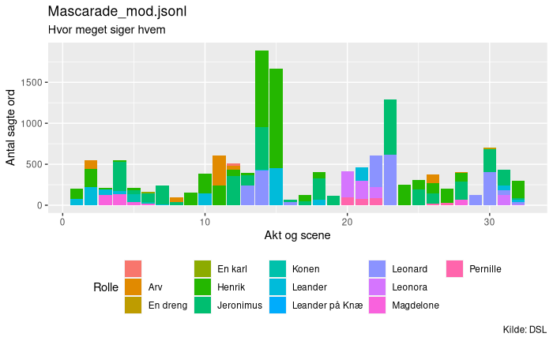

```r
my_summary %>%
  ggplot(aes(fill = speaker, y = words, x = scene_index)) +
    geom_bar(stat="identity") +
    theme(legend.position="bottom") +
    labs(
      title = my_file,
      subtitle = "Hvor meget siger hvem",
      caption = "Kilde: DSL",
      fill = "Rolle"
    ) +
  xlab("Akt og scene") +
  ylab("Antal sagte ord")
```

## Sammenlæg forskellige stavemåde af samme rolle

I ovenstående diagram ser vi, at flere roller optræder med flere stavemåder. Det kan vi heldigvis nemt håndtere.

Først laver vi en liste over alle roller i fx Barselsstuen Husk at ændre titel

```r
print(my_summary %>%
        ungroup() %>%
  select(speaker) %>%
  distinct(speaker) %>%
  arrange(speaker), n=60)
```

| speaker |
| --- |
| Arv |
| En dreng |
| En karl |
| Henrik |
| Jeronimus |
| Konen |
| Leander |
| Leander på Knæ |
| Leonard |

[output cut: 3 more lines]

Vi kan nu bruge to R funktioner: `if_else()` og `%in%`. Den første har tre argumenter. Det første er et logisk udtryk. Hvis dette udtryk er sandt, returneres resultatet af det andet argument. Hvis udtrykket er falsk, returneres resultatet af det tredje argument. Fx

```r
if_else(2==2, "Korrekt", "FAKE NEWS")
```

```
[1] "Korrekt"
```

```r
if_else("Trump"=="Klog", "Korrekt", "FAKE NEWS")
```

```
[1] "FAKE NEWS"
```

Vi vil også benytte funktionen `%in%`, som tjekker for om det der står til venstre er indeholdt i den liste der står til højre. Fx

```r
12 %in% c(1,2,3,4)
```

```
[1] FALSE
```

```r
12 %in% c(1, 2, 3, 12, 24)
```

```
[1] TRUE
```

Med de to funktioner, kan vi nu skrive denne kode Husk at disse ændringer er lavet til “Barselstuen”

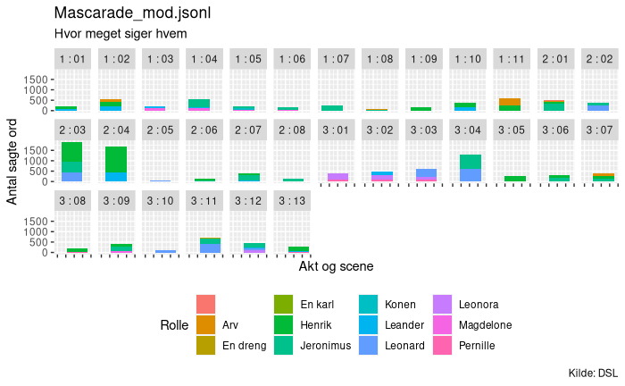

```r
my_summary %>% pull(scene_number) %>% max() -> number_of_scenes

my_summary %>%
  ungroup() %>%

  # count all versions of Leander as one
  mutate(
    speaker = if_else(speaker %in% c("Leander", "Leander på Knæ"), "Leander", speaker)) %>%

  # count all versions of Barselskvinden as one
  mutate(
    speaker = if_else(speaker %in% c("Barselskonen", "Barselskvinden", "Barselsqvinde"), "Barselskvinden", speaker)) %>%

  # Count all versions of kællingen as one
  mutate(
    speaker = if_else(speaker %in% c("Kælling", "Kællingen"), "Kællingen", speaker)) %>%

  ggplot(aes(fill = speaker, y = words, x = scene_index)) +
    geom_bar(stat="identity", width = 50) +
    theme(legend.position="bottom") +
    labs(
      title = my_file,
      subtitle = "Hvor meget siger hvem",
      caption = "Kilde: DSL",
      fill = "Rolle"
    ) +
  xlab("Akt og scene") +
  ylab("Antal sagte ord") +
  facet_wrap(~act_scene, ncol=number_of_scenes, strip.position = "top")+
  theme(axis.text.x=element_blank())
```

# Tilføj generel sammenlægning af forskellige stavemåde af samme rolle ved hjælp af excelarket

## Indlæs Excelarket

```r
variants <- read_excel(here("Rolleliste.xlsx")) %>%
     unnest_tokens(variant, Alias, token = "regex", pattern = ", ") %>%
    mutate(
      Karakter = tolower(Karakter),
      variant = tolower(variant)
    )
```

```
* `` -> ...4
```

```r
variants
```

| Filnavn | Karakter | ...4 | variant |
| --- | --- | --- | --- |
| Abracadabra_mod.jsonl | leander | NA | leander |
| Abracadabra_mod.jsonl | leander | NA | lenader |
| Artaxerxes_mod.jsonl | arbaces | NA | arbaces |
| Artaxerxes_mod.jsonl | arbaces | NA | arbaces sagte. |
| Artaxerxes_mod.jsonl | arbaces | NA | arbaces. |
| Artaxerxes_mod.jsonl | artaxerxes | NA | artaxerxes |
| Artaxerxes_mod.jsonl | artaxerxes | NA | artaxerxes alleene. |
| Artaxerxes_mod.jsonl | artaxerxes | NA | artaxerxes. |
| Artaxerxes_mod.jsonl | semira | NA | semira |
| Artaxerxes_mod.jsonl | semira | NA | semira. |

[output cut: 218 more lines]

## Anvend Excelarket

```r
(my_play %>%
  mutate(speaker = tolower(speaker)) %>%
  left_join(variants, by = c("filename"="Filnavn", "speaker"="variant")) %>%
  mutate(speaker = if_else(!is.na(Karakter), Karakter, speaker)) %>%
  distinct -> my_play)
```

| filename | act | act_number | docTitle | index | scene | scene_number | speaker | speaker_stage | spoke | stage | title | type | year | Karakter | ...4 |
| --- | --- | --- | --- | --- | --- | --- | --- | --- | --- | --- | --- | --- | --- | --- | --- |
| Mascarade_mod.jsonl | Første akt | 1 | Maskerade Komedie | 1 | Scene 1 | 1 | NA | NA | NA | Leander, Henrik | Maskerade | 1 | (1724) | NA | NA |
| Mascarade_mod.jsonl | Første akt | 1 | Maskerade Komedie | 2 | Scene 1 | 1 | leander | (i sin slåbrok gnikkende sine øjne) | NA | NA | Maskerade | 3 | (1724) | leander | NA |
| Mascarade_mod.jsonl | Første akt | 1 | Maskerade Komedie | 3 | Scene 1 | 1 | leander | NA | Henrik, hvad er klokken? | NA | Maskerade | 4 | (1724) | leander | NA |
| Mascarade_mod.jsonl | Første akt | 1 | Maskerade Komedie | 4 | Scene 1 | 1 | henrik | (gispende) | NA | NA | Maskerade | 3 | (1724) | NA | NA |
| Mascarade_mod.jsonl | Første akt | 1 | Maskerade Komedie | 5 | Scene 1 | 1 | henrik | NA | Klokken går nok til frokost, herre, men jeg ved ikke hvorfor vi skal stå så tidlig op. Se engang på uret, herre. | NA | Maskerade | 4 | (1724) | NA | NA |
| Mascarade_mod.jsonl | Første akt | 1 | Maskerade Komedie | 6 | Scene 1 | 1 | leander | NA | Hillemænd! Er det muligt? Skulle vi kunne have sovet så længe, fire timer over middag? Min klokke står på fire. | NA | Maskerade | 4 | (1724) | leander | NA |
| Mascarade_mod.jsonl | Første akt | 1 | Maskerade Komedie | 7 | Scene 1 | 1 | henrik | NA | Ej, det er ikke muligt, herre, det må være klokken fire om morgenen. | NA | Maskerade | 4 | (1724) | NA | NA |
| Mascarade_mod.jsonl | Første akt | 1 | Maskerade Komedie | 8 | Scene 1 | 1 | leander | NA | Du skal nok se at det er så lyst klokken fire i januar måned! | NA | Maskerade | 4 | (1724) | leander | NA |
| Mascarade_mod.jsonl | Første akt | 1 | Maskerade Komedie | 9 | Scene 1 | 1 | henrik | NA | Så må solen ikke gå rigtig da. Det kan jo umuligt være eftermiddag; thi nu stod vi først op. | NA | Maskerade | 4 | (1724) | NA | NA |
| Mascarade_mod.jsonl | Første akt | 1 | Maskerade Komedie | 10 | Scene 1 | 1 | leander | NA | Om solen går ikke ret, så ved jeg dog at mit ur ikke løber også gal; thi det er et engelsk ur. | NA | Maskerade | 4 | (1724) | leander | NA |

[output cut: 800 more lines]

## Gentag klargøring af data

```r
my_play %>%
  select(docTitle) %>%
  distinct() %>%
  pull(1,1) -> my_title

my_play %>%
  select(year) %>%
  distinct() %>%
  pull(1,1) -> my_year


my_play %>%
  # add a scene index for the x-axis
  rowwise() %>%
  mutate(scene_index = calc_scene_index(act_number, scene_number, act_length)) %>%

  # add an act_number:scene_number row
  mutate(act_scene = paste(act_number,":",str_pad(scene_number, 2, pad = "0"))) %>%

  # remove rows that are not dialogue
  filter(act != "", scene != "", !is.na(spoke)) %>%

  # select only the columns, that we are interested in
  select(scene_index, act_scene, act_number, scene_number, speaker, spoke) %>%

  # add the number of spoken words
  mutate(n_spoken_words = str_count(spoke, '\\w+')) %>%
  # remove the spoken words
  select(-spoke) %>%

  # group the play in scene_index and speaker, ignoring the test
  group_by(scene_index, act_scene, act_number, scene_number, speaker) %>%

  # Ensure that each speaker only appears once in each scene, i.e. sum the words spoken by each speaker
  # Lastly store the new data frame in a new reference for later use
  summarise(words = sum(n_spoken_words), act_number, scene_number) %>%
  distinct() -> my_summary
#print(barselsstuen_vis, n=60)
my_summary
```

| scene_index | act_scene | act_number | scene_number | speaker | words |
| --- | --- | --- | --- | --- | --- |
| 1 | 1 : 01 | 1 | 1 | henrik | 121 |
| 1 | 1 : 01 | 1 | 1 | leander | 80 |
| 2 | 1 : 02 | 1 | 2 | arv | 111 |
| 2 | 1 : 02 | 1 | 2 | henrik | 217 |
| 2 | 1 : 02 | 1 | 2 | leander | 223 |
| 3 | 1 : 03 | 1 | 3 | henrik | 17 |
| 3 | 1 : 03 | 1 | 3 | leander | 71 |
| 3 | 1 : 03 | 1 | 3 | magdelone | 126 |
| 4 | 1 : 04 | 1 | 4 | henrik | 21 |
| 4 | 1 : 04 | 1 | 4 | jeronimus | 361 |

[output cut: 77 more lines]

## Gentag visualisering

### Vi vil gerne have en linje/visuel adskillelse mellem akterne i graferne.

Det kan jeg simpelthen ikke få til at virke!

### Og stykkets titel og årstal tilføjes i header før filnavn.

Det er til gengæld nemt. Vi paster det bare ind i title.

```r
my_summary %>% pull(scene_number) %>% max() -> number_of_scenes

(new_act <- my_summary %>%
  ungroup %>%
  arrange(scene_index) %>%
  select(act_number, scene_number, scene_index) %>%
  distinct() %>%
  filter(scene_number==1) %>%
  mutate(line = scene_index + 0.5) %>%
  select(line) %>%
  tibble())
```

| line |
| --- |
| 1.5 |
| 12.5 |
| 20.5 |

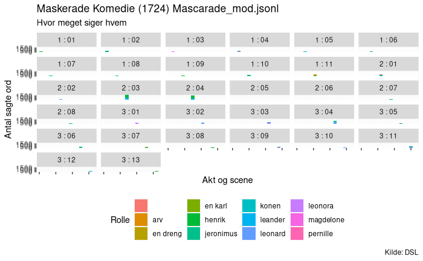

```r
my_summary %>%
  ggplot(aes(fill = speaker, y = words, x = scene_index)) +
    geom_bar(stat="identity", width = 2) +
    theme(legend.position="bottom") +
    labs(
      title = paste(my_title, my_year, my_file),
      subtitle = "Hvor meget siger hvem",
      caption = "Kilde: DSL",
      fill = "Rolle"
    ) +
  xlab("Akt og scene") +
  ylab("Antal sagte ord") +
  facet_wrap(~act_scene, strip.position = "top")+
  theme(axis.text.x=element_blank()) #+
  #scale_x_continuous(aes(scene_index, breaks = new_act))

  #theme(panel.grid.major.x = element_line(color = "gray10", size = .5))

  #geom_vline(aes(xintercept = line), new_act)

  ggsave(here("graphs/visualisering-ord-sagt", paste(my_file, ".hvor_meget_siger_hvem.pdf")), width=16, height=9)
```

#Brug funktion på alle stykker

```r
# Alle stykker som json filer
json_file_list <- list.files(here("test-data"), pattern = "*.jsonl")
# Alle stykker som visualiseringer af ord sagt
for(i in 2:length(json_file_list)) {
  print(json_file_list[i])
  #create_visual(json_file_list[i]) #funktionen virker ikke!
}
```

```
[1] "Barselstuen_mod.jsonl"
[1] "Bondedreng_mod.jsonl"
[1] "Brudgom_mod.jsonl"
[1] "De_u-synlige_mod.jsonl"
[1] "Den_11_Junii_mod.jsonl"
[1] "Den_Honnette_Ambition_mod.jsonl"
[1] "Den_Stundesloese_mod.jsonl"
[1] "Den_Vaegelsindede_1723_mod.jsonl"
[1] "Den_Vaegelsindede_1731_mod.jsonl"
[1] "Det_Arabiske_Pulver_mod.jsonl"
[1] "Diderich_mod.jsonl"
[1] "Erasmus_mod.jsonl"
[1] "GertWestphaler1723_mod.jsonl"
[1] "GertWestphaler1724_mod.jsonl"
[1] "Henrick_og_Pernille_mod.jsonl"
```

[output cut: 20 more lines]